# CS 372/472 & LRN_SCI 372/472

Designing Models + Extensions

Prof. Connor Bain

connor.bain@northwestern.edu

April 30, 2026

## Logistical Stuff

**Exercise 5**

- Is due on SUNDAY at 11:59pm via Canvas.
- Asks you to continue thinking about the Final Project for the course.

**Class on May 19th**

We will NOT have class on May 19th

## Purposes of Modeling

- Description
- Explanation
- Experimentation (or Prediction)
- Providing sources of analogy
- Communication / education
- Providing focal objects for dialogue
- Thought experiments

## Reference Pattern

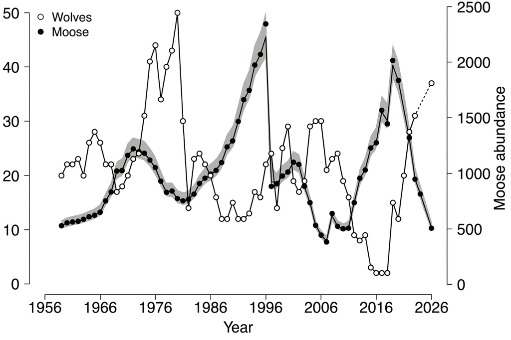

## What are the agents?

### Concentrate on the entities which are *most* relevant to our question.

### Carefully consider the granularity of the agent.

- Do we want to model individual animals, or do we want to model groups of animals?
- If we model grass, do we want to model individual blades of grass, or do we want to model clumps of grass?

## Design Spec

- Moving Agent Types: wolves & sheep
- Moving Agent Properties: energy, location, and heading
- Moving Agent Behaviors: move, die, reproduce, eat-sheep (wolves only), eat-grass (sheep only)
- Environmental Agent Types: grass
- Environmental Agent Properties: location, regrowth time
- Environmental Agent Behaviors: regrow
- Model Parameters: Number of sheep & wolves at start, movement cost, energy gain from eating, grass regrowth rate
- Measures: population levels of wolves and sheep over time

## Design Spec (cont.)

- Time Step:
  - Agents move
  - Agents eat
  - Agents die
  - Agents reproduce
  - Grass regrows

# Let’s build it!

# Agent Cognition

## What do the agents know? How do they make decisions?

- So far we’ve had a couple of answers to this:
  - “Non-agentic” agents that just move randomly
  - “Agentic” agents that mostly move randomly…but also have some “goal-directed” behavior (e.g., sheep eat grass, wolves eat sheep)
- Can we (*should we*) make the agents smarter?

## Agent Cognition in Wolf-Sheep

**Can we make these agents “smarter” or are they already “smart enough” to show the behavior we’re interested in?**

- What are some ways we could make the wolves “smarter”?
- What are some ways we could make the sheep “smarter”?

**Warning**

- We’ll also revisit this idea in a couple of weeks to break down the design of “smarter” agents in more detail.

## A different approach

- What if instead, we offloaded this work into other “agents” (read: humans)
- We could have a human player control the wolves, and another human player control the sheep.
- We call this a participatory simulation Wilensky and Stroup (1999)
  - The tool inside NetLogo that supports this is called [HubNet](https://docs.netlogo.org/hubnet)

# Extensions in NetLogo

## Outside the NetLogo core

- NetLogo is specifically designed to have a core or base set of features that are for ABM.
- However, there’s also lots of extensions that can push past the boundaries of just base ABM
  - `csv` extension for reading/writing CSV files
  - `gis` extension for working with geospatial data
  - `python` extension for interfacing with Python code
  - `network` extension for working with networks/graphs
  - `arduino` extension for interfacing with Arduino hardware
  - and more

# Final Project Details

## Overview

**Goal**: The goal of the project is to design, implement, and evaluate a substantial agent-based model of an emergent phenomenon that is of interest to you.

## Deliverables

**What’s Due**:

- A completed agent-based model(s) implemented in NetLogo at the quality-level of those in the NetLogo Model’s Library.
- A final paper describing your model, the design process, and the results of your evaluation.
  - For 372 students, this will be structured as a lab report (on the order of 5 to 7 pages)
  - For 472 students, this will be structured as a research paper for a conference in your field (on the order of 8 to 10 pages)
- A final “firehose presentation slide” for your model that you will present to the class on the next to last day of class.
- A final “poster” for your model that you will present to the class (and the greater NU community) on the last day of class.

## Model Details

1. The code should be readable (e.g., well structured, well written, and well commented) and close-to-understandable by a person who is becoming familiar with NetLogo.
2. The Info tab should include all the main parts in the NetLogo Models Library. It should succinctly and accurately describe the phenomenon being modeled. A reader who does not have any background in the subject should be able to at least garner some understanding of what is going on.
3. The interface should be *intuitive* and it should be possible to use the model (at least tinker with it) without having to refer to the Info tab immediately.
4. Refer to the [NetLogo Style Guide](https://github.com/NetLogo/models/wiki/NetLogo-Style-Guide) for guidance.

## Additional Requirement for 472

1. Create additional related, but substantially distinct models
2. Incorporate some other advanced NetLogo feature (such as interfacing with hardware or using the LevelSpace, GIS, Python, or Network extension) into a complementary model
3. Create a HubNet activity that complements the NetLogo model

## Paper / Report Details

This is the final “evolution” of the document that starts as your Final Project Design Proposal which we will discuss in detail next week:

- A high-level picture overview
- description of what can be learned
- motivation/rationale for the project, description of rules/model implementation

But it should be polished and also contain substantial sections describing your results and analysis of the model.

> For 372 students this will look more like a lab report, and for 472 students this will look more like a research paper for a conference in your field.

## Analysis Possibilities

- Exploration of parameter space and possible regimes
- Comparison with real world data / reference pattern
- Empirical analysis
  - Report on an actual case of someone (or some group) actually using your model.

> 400-level student papers are expected to be both more grounded in the relevant academic literature and more rigorous/extensive in the model analysis, at a standard that could put it on a trajectory towards publication.

## Final Project Activity

### Are you designing *puppets* or *agents*?

### Are you answering a *question* or are you designing a *toy*?

### Are you focusing on the *process* of modeling, or are you focusing on the *product* of modeling?

## References

Wilensky, Uri J, and Walter Stroup. 1999. *Learning Through Participatory Simulations: Network-Based Design for Systems Learning in Classrooms*.